# Analiza danych

Projekt

Lidia

Politechnika Krakowska

```r
library(tidyverse)
library(dplyr)
library(tibble)
```

Wczytajmy plik danych *iris*, a następnie wyświetlmy jego zawartość.

```r
flowers <- as_tibble(iris)
flowers
```

| Sepal.Length | Sepal.Width | Petal.Length | Petal.Width | Species |
| --- | --- | --- | --- | --- |
| 5.1 | 3.5 | 1.4 | 0.2 | setosa |
| 4.9 | 3.0 | 1.4 | 0.2 | setosa |
| 4.7 | 3.2 | 1.3 | 0.2 | setosa |
| 4.6 | 3.1 | 1.5 | 0.2 | setosa |
| 5.0 | 3.6 | 1.4 | 0.2 | setosa |
| 5.4 | 3.9 | 1.7 | 0.4 | setosa |
| 4.6 | 3.4 | 1.4 | 0.3 | setosa |
| 5.0 | 3.4 | 1.5 | 0.2 | setosa |
| 4.4 | 2.9 | 1.4 | 0.2 | setosa |
| 4.9 | 3.1 | 1.5 | 0.1 | setosa |

[output cut: 140 more lines]

W podanej powyżej tabeli danych przedstawione są wartośći długości i szerokości działek kielicha wraz z długością oraz szerokością płatkóW dla odpowiednich gatunków roślin $\textit{setosa, versicolor, virginica}$.

Aby ułatwić przegląd danych względem podzielmy następująco tabelkę względem gatunków.

```r
colnames(flowers) <- c("Działki_Kielicha_Długość", "Działki_Kielicha_Szerokość","Długość_Płatka", "Szerokość_Płatka","Gatunek")
```

```r
data_split <- split(flowers,flowers$Gatunek)
```

```r
setosa <- filter(flowers, Gatunek == "setosa")
setosa
```

| Działki_Kielicha_Długość | Działki_Kielicha_Szerokość | Długość_Płatka | Szerokość_Płatka | Gatunek |
| --- | --- | --- | --- | --- |
| 5.1 | 3.5 | 1.4 | 0.2 | setosa |
| 4.9 | 3.0 | 1.4 | 0.2 | setosa |
| 4.7 | 3.2 | 1.3 | 0.2 | setosa |
| 4.6 | 3.1 | 1.5 | 0.2 | setosa |
| 5.0 | 3.6 | 1.4 | 0.2 | setosa |
| 5.4 | 3.9 | 1.7 | 0.4 | setosa |
| 4.6 | 3.4 | 1.4 | 0.3 | setosa |
| 5.0 | 3.4 | 1.5 | 0.2 | setosa |
| 4.4 | 2.9 | 1.4 | 0.2 | setosa |
| 4.9 | 3.1 | 1.5 | 0.1 | setosa |

[output cut: 40 more lines]

```r
versicolor<- filter(flowers, Gatunek == "versicolor")
versicolor
```

| Działki_Kielicha_Długość | Działki_Kielicha_Szerokość | Długość_Płatka | Szerokość_Płatka | Gatunek |
| --- | --- | --- | --- | --- |
| 7.0 | 3.2 | 4.7 | 1.4 | versicolor |
| 6.4 | 3.2 | 4.5 | 1.5 | versicolor |
| 6.9 | 3.1 | 4.9 | 1.5 | versicolor |
| 5.5 | 2.3 | 4.0 | 1.3 | versicolor |
| 6.5 | 2.8 | 4.6 | 1.5 | versicolor |
| 5.7 | 2.8 | 4.5 | 1.3 | versicolor |
| 6.3 | 3.3 | 4.7 | 1.6 | versicolor |
| 4.9 | 2.4 | 3.3 | 1.0 | versicolor |
| 6.6 | 2.9 | 4.6 | 1.3 | versicolor |
| 5.2 | 2.7 | 3.9 | 1.4 | versicolor |

[output cut: 40 more lines]

```r
virginica <- filter(flowers, Gatunek == "virginica")
virginica
```

| Działki_Kielicha_Długość | Działki_Kielicha_Szerokość | Długość_Płatka | Szerokość_Płatka | Gatunek |
| --- | --- | --- | --- | --- |
| 6.3 | 3.3 | 6.0 | 2.5 | virginica |
| 5.8 | 2.7 | 5.1 | 1.9 | virginica |
| 7.1 | 3.0 | 5.9 | 2.1 | virginica |
| 6.3 | 2.9 | 5.6 | 1.8 | virginica |
| 6.5 | 3.0 | 5.8 | 2.2 | virginica |
| 7.6 | 3.0 | 6.6 | 2.1 | virginica |
| 4.9 | 2.5 | 4.5 | 1.7 | virginica |
| 7.3 | 2.9 | 6.3 | 1.8 | virginica |
| 6.7 | 2.5 | 5.8 | 1.8 | virginica |
| 7.2 | 3.6 | 6.1 | 2.5 | virginica |

[output cut: 40 more lines]

Za pomocą wykresu pudełkowego tzn. boxplota zwizualizujmy następujące dane dla odpowiednich gatunków kwiatów.

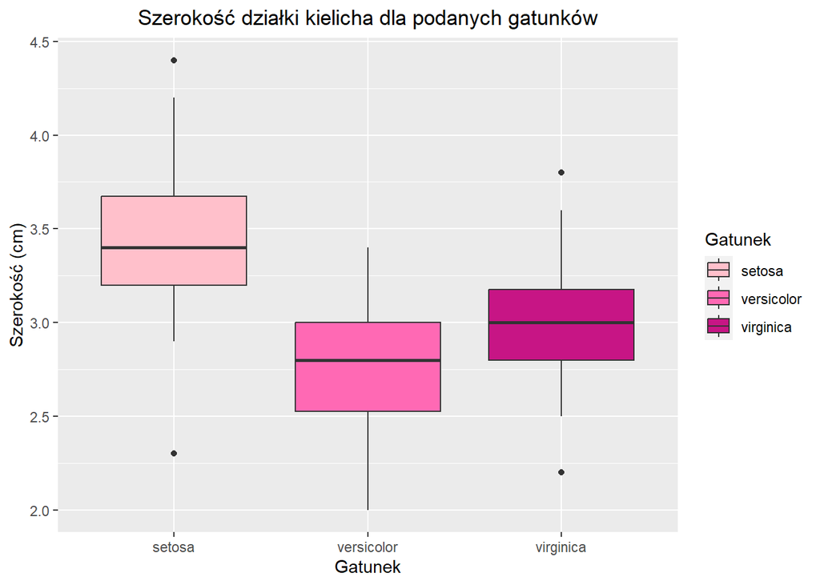

```r
ggplot(data=flowers, aes(x=Gatunek, y= Działki_Kielicha_Szerokość,fill = Gatunek)) + geom_boxplot()+ scale_fill_manual(values=c("#FFC0CB", "#FF69B4", "#C71585")) + ggtitle("Szerokość działki kielicha dla podanych gatunków") +
  theme(plot.title = element_text(hjust = 0.5)) + xlab("Gatunek") + ylab("Szerokość (cm)")
```

Powyższy wykres pudełkowy dostarcza nam informacje na temat mediany, najmniejszej oraz największej wartości szerokości działek kielicha dla odpowiednich gatunków. Mediana szerokości działek klielicha dla gatunków wyznacza pozioma czarna kreska zawarta w pudełkach.

###### Mediana szerokości działekkielicha

$\textit{setosa}$ przyjmuję wartość po między 3.25-3.5cm, $\textit{versicolor}$ w przedziałach 2.25-3cm, $\textit{virginica}$ wynosi ona dokładnie 3cm.

Najmniejsze oraz największe wartości danych zawarte są na końcach tzn.$\textit{wąsów}$ wykresu pudełkowego.

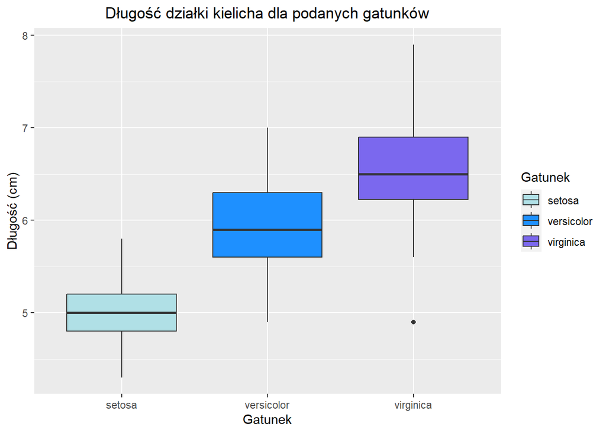

```r
ggplot(data=flowers, aes(x=Gatunek, y= Działki_Kielicha_Długość,fill = Gatunek)) + geom_boxplot()+ scale_fill_manual(values=c("#B0E0E6", "#1E90FF", "#7B68EE")) + ggtitle("Długość działki kielicha dla podanych gatunków") +
  theme(plot.title = element_text(hjust = 0.5)) + xlab("Gatunek") + ylab("Długość (cm)")
```

### Mediana długości dzialek kielicha

$\textit{setosa}$ przyjmuję wartość 5cm, $\textit{versicolor}$ w przedziałach 5.5 - 6cm, $\textit{virginica}$ wynosi ona dokładnie 6,5cm.

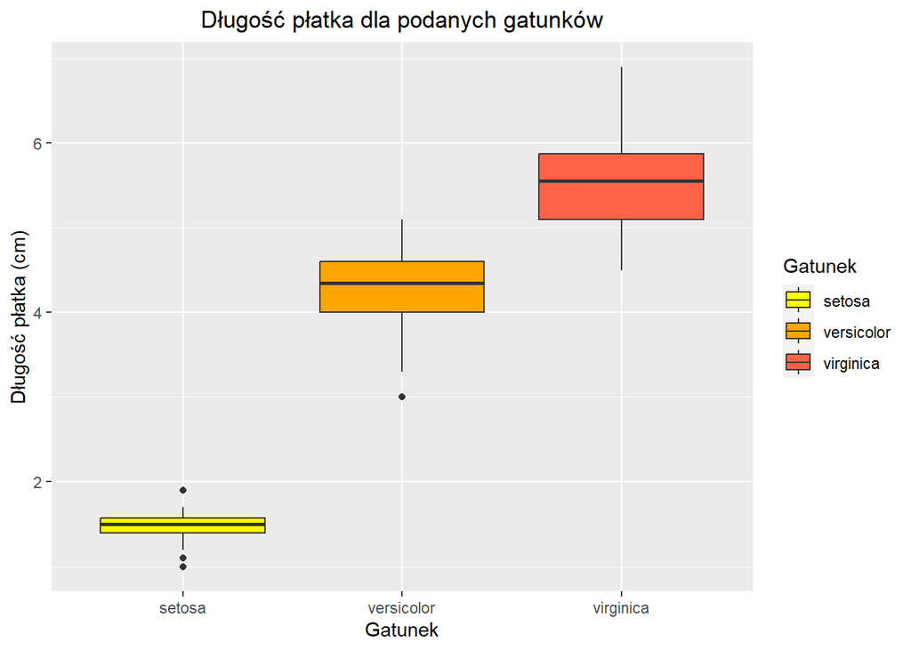

```r
ggplot(data=flowers, aes(x=Gatunek, y= Długość_Płatka,fill = Gatunek)) + geom_boxplot()+ scale_fill_manual(values=c("#FFFF00", "#FFA500", "#FF6347")) + ggtitle("Długość płatka dla podanych gatunków") +
  theme(plot.title = element_text(hjust = 0.5)) + xlab("Gatunek") + ylab("Długość płatka (cm)")
```

###### Mediana długości płatka

$\textit{setosa}$ przyjmuję wartość między $1-2$cm, $\textit{versicolor}$ w przedziałach $4 - 5$cm, $\textit{virginica}$ wynosi ona $5-6$cm.

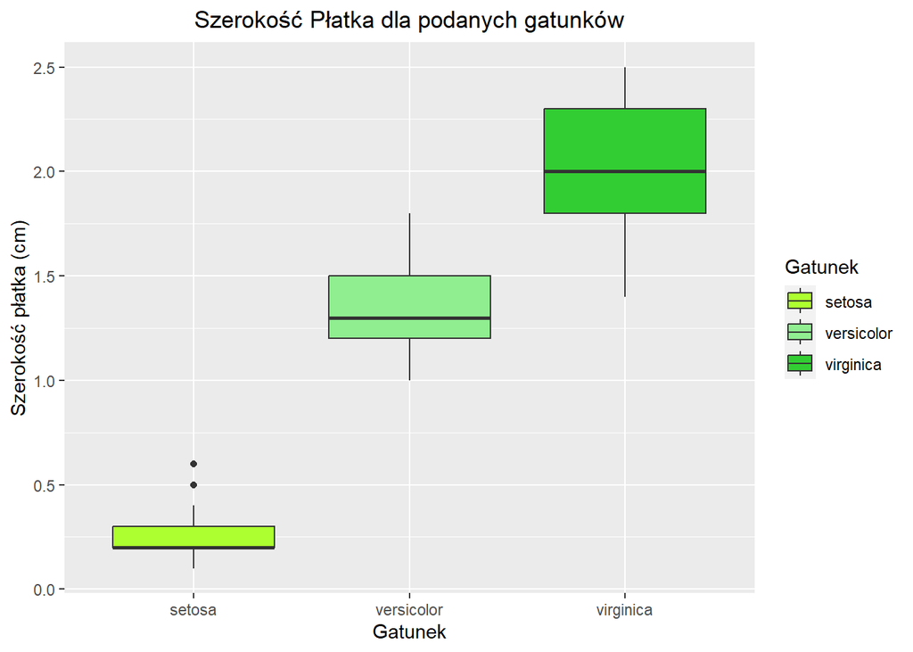

```r
ggplot(data=flowers, aes(x=Gatunek, y=Szerokość_Płatka,fill = Gatunek)) + geom_boxplot()+ scale_fill_manual(values=c("#ADFF2F", "#90EE90", "#32CD32")) + ggtitle("Szerokość Płatka dla podanych gatunków") + theme(plot.title = element_text(hjust = 0.5)) + xlab("Gatunek") + ylab("Szerokość płatka (cm)")
```

###### Mediana szerokośći płatka

$\textit{setosa}$ przyjmuję wartość 0,25cm, $\textit{versicolor}$ w przedziałach 1,25 - 1,5cm, $\textit{virginica}$ wynosi ona 2cm.

Na poniższych wykresach kropkowych porównajmy następujące zalezności między cechami gatunków.

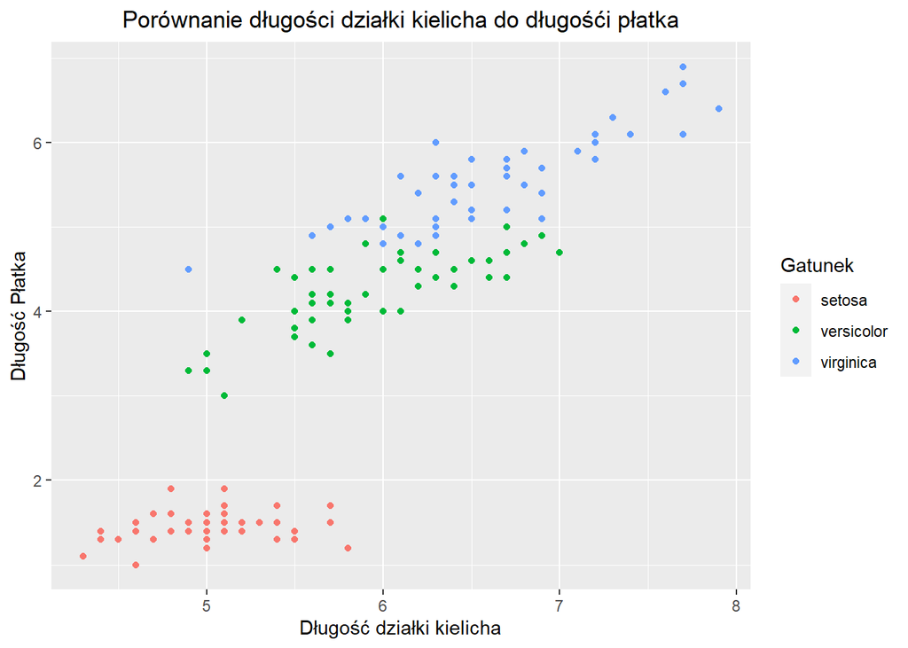

```r
ggplot(data=flowers, aes(x=Działki_Kielicha_Długość, y=Długość_Płatka, color=Gatunek))  + geom_point()+ggtitle("Porównanie długości działki kielicha do długośći płatka") +
  theme(plot.title = element_text(hjust = 0.5)) + ylab('Długość Płatka') + xlab('Długość działki kielicha')
```

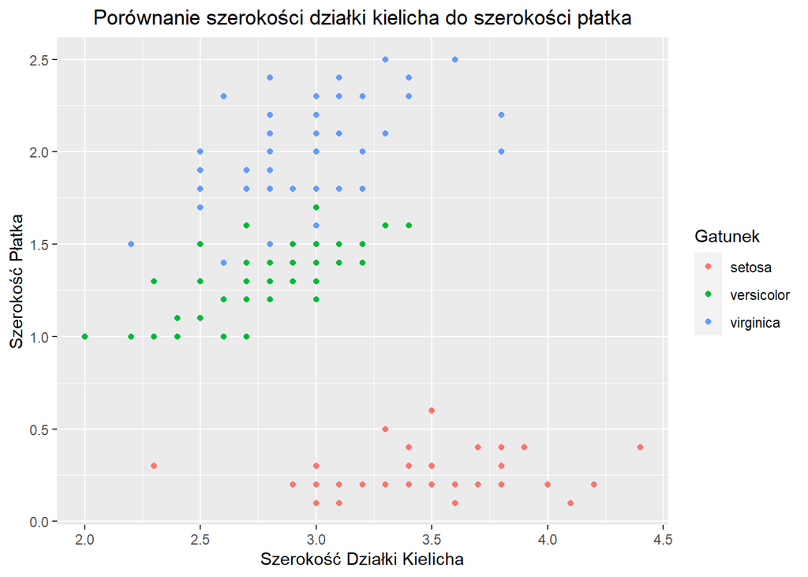

```r
ggplot(data=flowers, aes(x=Działki_Kielicha_Szerokość, y=Szerokość_Płatka, color=Gatunek)) + geom_point() + ggtitle("Porównanie szerokości działki kielicha do szerokości płatka") +
  theme(plot.title = element_text(hjust = 0.5))+ylab('Szerokość Płatka') + xlab('Szerokość Działki Kielicha')
```

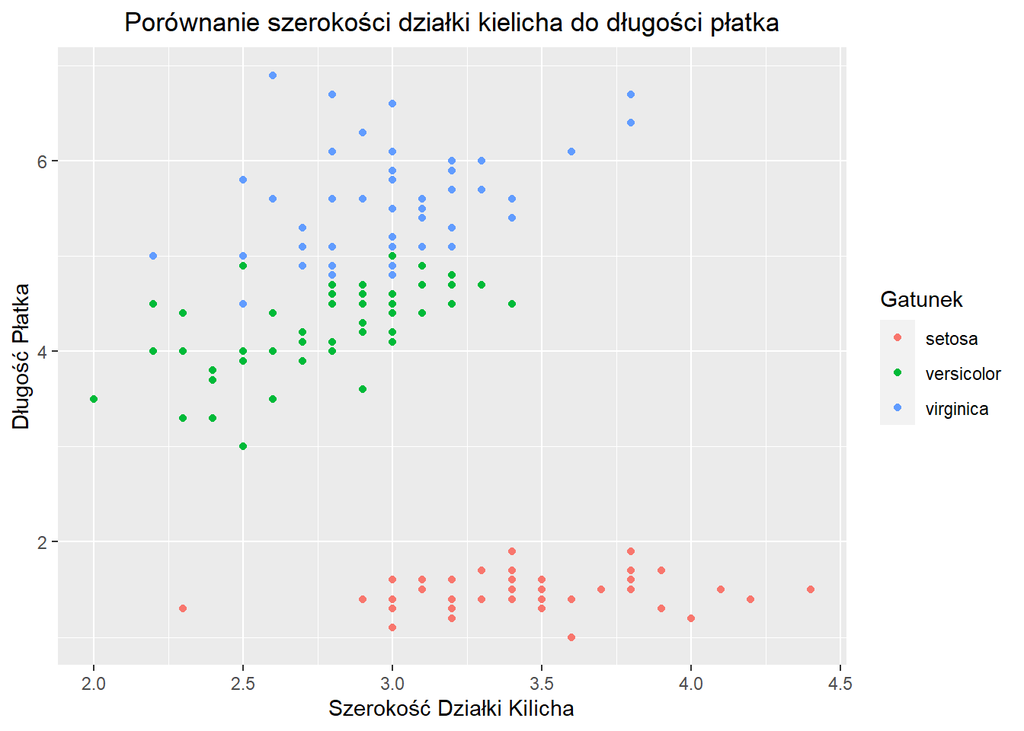

```r
ggplot(data=flowers, aes(x=Działki_Kielicha_Szerokość, y=Długość_Płatka, color=Gatunek)) + geom_point() + ggtitle("Porównanie szerokości działki kielicha do długości płatka") +
  theme(plot.title = element_text(hjust = 0.5))+ylab('Długość Płatka') + xlab('Szerokość Działki Kilicha')
```

Wykorzystując histogram zaczerpmy informacje na temat długości, szerokości działek kielicha oraz płatków dla gatunków.

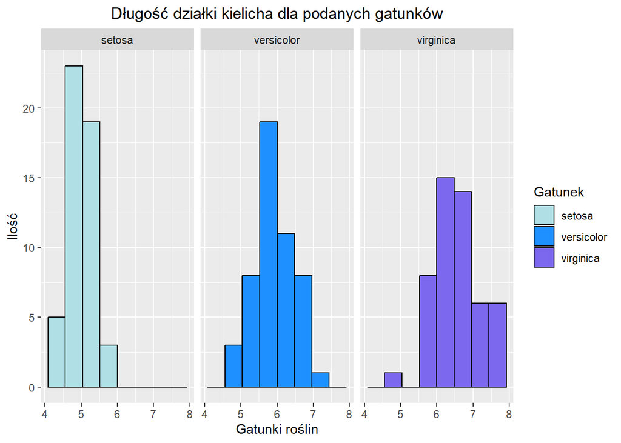

```r
ggplot(data = flowers , aes(x=Działki_Kielicha_Długość,fill=Gatunek)) + geom_histogram(bins = 17,binwidth = 0.48,color='black') + facet_wrap(~Gatunek)+scale_fill_manual(values=c("#B0E0E6", "#1E90FF", "#7B68EE")) + ggtitle("Długość działki kielicha dla podanych gatunków") +
  theme(plot.title = element_text(hjust = 0.5)) + xlab("Gatunki roślin") + ylab("Ilość")
```

Patrząc na histogram dla pierwszego gatunku zauważmy, że długość działek kielicha dla wartości między 4,5-5cm przyjmuję największa liczba populaci. Dla drugiego gatunku jest to przedział 5.5-6cm, a dla ostatniego mieści się ona między 6-6,5cm. Najniejsze wartości dla długości działek kielicha przyjmuję $\textit{setosa}$ za to największe $\textit{virginica}$.

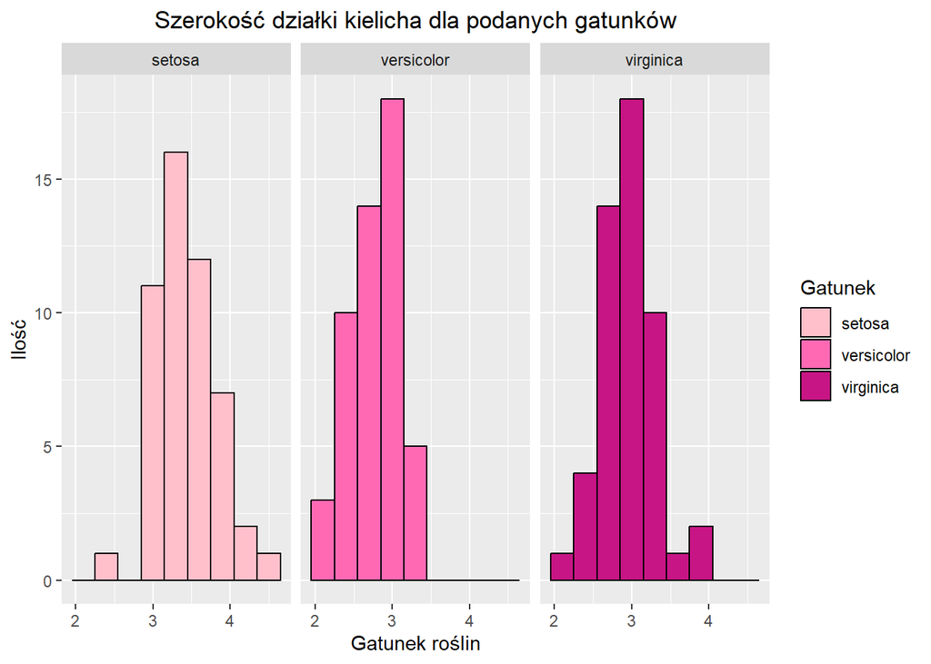

```r
ggplot(data = flowers , aes(x=Działki_Kielicha_Szerokość,fill=Gatunek)) + geom_histogram(bins = 17,binwidth = 0.3,color='black') + facet_wrap(~Gatunek)+ scale_fill_manual(values=c("#FFC0CB", "#FF69B4", "#C71585")) + ggtitle("Szerokość działki kielicha dla podanych gatunków") +
  theme(plot.title = element_text(hjust = 0.5)) + xlab("Gatunek roślin") + ylab("Ilość")
```

Szerokość działek kielicha dla $\textit{setosa}$przyjmująca wartość między 3-3,5cm przyjmuję największa liczba populaci. Dla drugiego gatunku jest to przedział mniej więcej 2.8-3,1cm, a dla ostatniego mieści się w podobnych przedziałach jak dla $\textit{versicolor}$. Największe wartości dla szerokości działek kielicha przyjmuję $\textit{setosa}$ za to najmniejsze $\textit{versicolor}$.

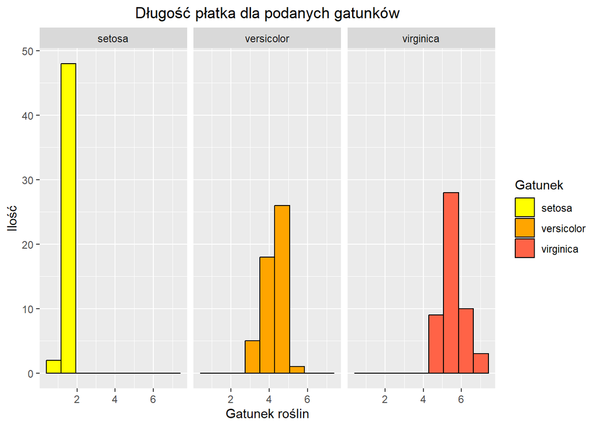

```r
ggplot(data = flowers , aes(x=Długość_Płatka,fill=Gatunek)) + geom_histogram(bins = 17,binwidth = 0.78,color='black') + facet_wrap(~Gatunek)+
  scale_fill_manual(values=c("#FFFF00", "#FFA500", "#FF6347")) + ggtitle("Długość płatka dla podanych gatunków") +
  theme(plot.title = element_text(hjust = 0.5)) + xlab("Gatunek roślin") + ylab("Ilość")
```

Długość płatka dla $\textit{setosa}$ wynosząca między 1,5-2cm przyjmuję największa liczba populaci. Dla $\textit{versicolor}$ jest to przedział mniej więcej 4,2-5.1cm, a dla ostatniego gatunku mieści się w przedziałach około 5-6cm. Największe wartości dla długości płatka przyjmuję $\textit{virginica}$ za to najmniejsze $\textit{setosa}$.

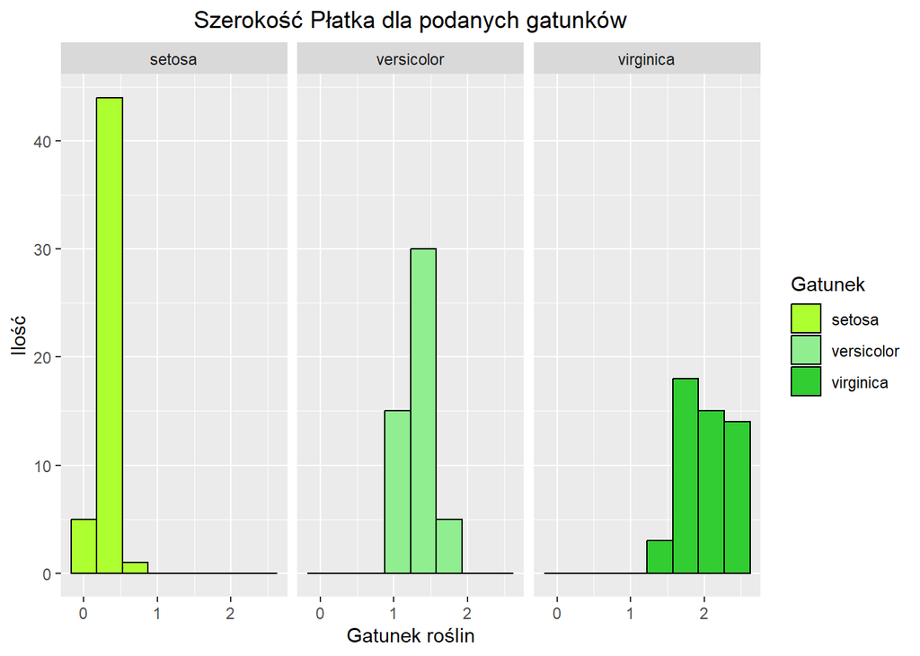

```r
ggplot(data = flowers , aes(x=Szerokość_Płatka,fill=Gatunek)) + geom_histogram(bins = 15,binwidth = 0.35,color='black') +scale_fill_manual(values=c("#ADFF2F", "#90EE90", "#32CD32")) + ggtitle("Szerokość Płatka dla podanych gatunków") + theme(plot.title = element_text(hjust = 0.5)) + xlab("Gatunek roślin") + ylab("Ilość")+ facet_wrap(~Gatunek)
```

# Test Parametryczny

Sprawdźmy szerokość działek kielicha ma wpływ na długość płatka dla pojedynczych gatunków. Sprawdźmy istotność statystyczną współczynnika korelacji na poziomie istotności $\alpha=0.05$ za pomocą metody parametrycznej.

Aby zweryfikować takie stwierdzenie wykonajmy test korelacji. W związku z tym przyjmijmy następującą hipotezę zerową ${H_0}:\delta=0$ - szerokość działek kielicha nie ma wpływ na długość płatka, i alternatywną ${H_1}:\delta\neq0$ - szerokość działek kielicha ma wpływ na długość płatka.

```r
cor.test(setosa$Działki_Kielicha_Szerokość,setosa$Długość_Płatka)
```

```
##
##  Pearson's product-moment correlation
##
## data:  setosa$Działki_Kielicha_Szerokość and setosa$Długość_Płatka
## t = 1.2511, df = 48, p-value = 0.217
## alternative hypothesis: true correlation is not equal to 0
## 95 percent confidence interval:
##  -0.1058851  0.4345536
## sample estimates:
##    cor
## 0.1777
```

Jako że wartość $p = 0,217$, czyli jest wyższa od przyjętego poziomu istotności wynoszącego $\alpha =0.05$, to w tym wypadku nie możemy odrzucić hipotezy zerowej mówiązej nam, że szerokość działek kielicha dla ${\textit{setosa}}$ nie ma wpływu na długość płatka. Dodatkowo na podstawie współczynika korelacji możemy stwierdzić, że istnieje słaba zależność między rozważanymi zmiennymi.

```r
cor.test(virginica$Działki_Kielicha_Szerokość,virginica$Długość_Płatka)
```

```
##
##  Pearson's product-moment correlation
##
## data:  virginica$Działki_Kielicha_Szerokość and virginica$Długość_Płatka
## t = 3.0331, df = 48, p-value = 0.003898
## alternative hypothesis: true correlation is not equal to 0
## 95 percent confidence interval:
##  0.1381146 0.6111677
## sample estimates:
##       cor
## 0.4010446
```

Wartość $p = 0,003898$, czyli jest niższa od przyjętego poziomu istotności $\alpha =0.05$, to odrzucamy hipotezę zerową. W tym wypadku możemy założyć, że szerokość działek kielicha dla ${\textit{virginica}}$ ma wpływu na długość płatka. Dodatkowo na podstawie współczynika korelacji możemy stwierdzić, że istnieje dość przeciętna zależność między rozważanymi zmiennymi.

```r
cor.test(versicolor$Działki_Kielicha_Szerokość,versicolor$Długość_Płatka)
```

```
##
##  Pearson's product-moment correlation
##
## data:  versicolor$Działki_Kielicha_Szerokość and versicolor$Długość_Płatka
## t = 4.6893, df = 48, p-value = 2.302e-05
## alternative hypothesis: true correlation is not equal to 0
## 95 percent confidence interval:
##  0.3343378 0.7256533
## sample estimates:
##       cor
## 0.5605221
```

Wartość $p = 2,302\cdot10^{-5}$, czyli jest niższa od przyjętego poziomu istotności $\alpha =0.05$, to w tym wypadku odrzucamy hipotezę zerową. Możemy więc przyjąc hipotezę alternatywną i założyć,że szerokość działek kielicha dla ${\textit{versicolor}}$ ma wpływu na długość płatka. Dodatkowo na podstawie współczynika korelacji możemy stwierdzić, że istnieje wysoka zależność między rozważanymi zmiennymi. Inaczej mówiąc im bardziej szersza działka kielicha tym dłuższy jest płatek.

Podsumowując największa zależność między szerokością działki kielicha, a długością płatka wystepuję dla ${\textit{\versicolor}}$, za to najsłabsza dla ${\textit{setosa}}$.

# Test Permutacyjny

```r
n <-50000
corelation<-rep(0,n)
for (i in 1:n) {
  sample_1<-sample(versicolor$Szerokość_Płatka,50,replace = FALSE)
  corelation[i] <- cor(versicolor$Długość_Płatka,sample_1)
}
quantile(corelation,c(0.025,0.975))
```

```
##       2.5%      97.5%
## -0.2828667  0.2771567
```

```r
n <-50000
corelation<-rep(0,n)
for (i in 1:n) {
  sample_2<-sample(setosa$Szerokość_Płatka,50,replace = FALSE)
  corelation[i] <- cor(setosa$Długość_Płatka,sample_2)
}
quantile(corelation,c(0.025,0.975))
```

```
##       2.5%      97.5%
## -0.2816737  0.2870261
```

```r
n <-50000
corelation<-rep(0,n)
for (i in 1:n) {
  sample_3<-sample(virginica$Szerokość_Płatka,50,replace = FALSE)
  corelation[i] <- cor(virginica$Długość_Płatka,sample_3)
}
quantile(corelation,c(0.025,0.975))
```

```
##       2.5%      97.5%
## -0.2810705  0.2763313
```